# Vim, the editor

[figure not shown]

# Other text editors

## Your typical editor works like this...

- When you type almost any key, the corresponding character (letter, number, symbol, or whitespace) appears at the cursor
- Certain special keys do special operations (control, alt, command, super)
- For a GUI app, you can/must click menus for other functionality

# Vim is different

## Vim has *modes*

**Normal**

for almost everything except typing!

**Insert**

for typing

**Visual**

for highlighting a region to operate on

(and others you don't need to know about)

# The keyboard is your friend

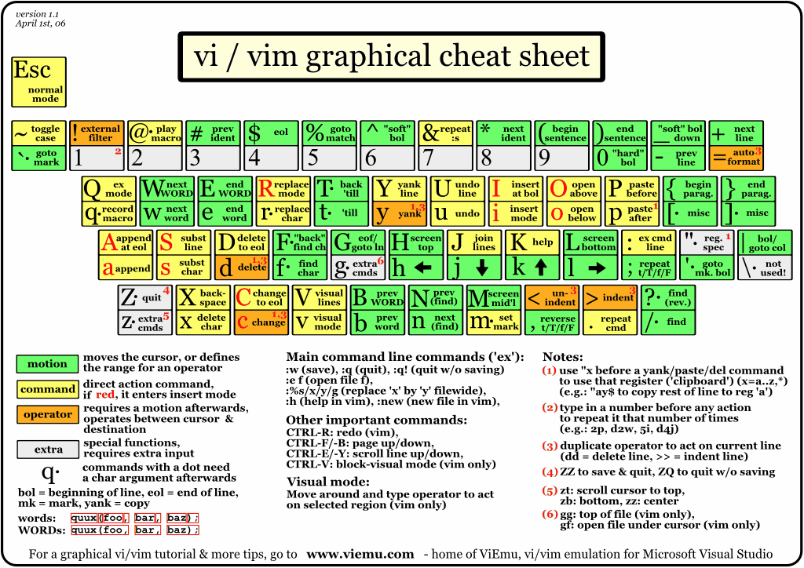

# For the impatient

- Start vim in terminal: `$ vi test.txt`
- Press `i` to enter insert mode
- Type to your heart's content
- When you're done, hit `Esc` to leave insert mode
- Then type `:w` to save your document
- Then type `:q` to quit
  - if you have unsaved changes, vim will complain
  - to save, see previous, or do `:wq` in one step
  - to discard changes and quit, do `:q!`

# Normal mode

### Now that you've seen that you *can* actually type in vim, let's learn about the magic of Normal mode!

# Moving around ("motions")

**Stepping**

- by line: up `k`, down `j`
- by character: forward `l`, backward `h`
- by word: forward `w`, backward `b`
- by sentence: forward `)`, backward `(`
- by paragraph: forward `}`, backward `{`

# Moving around ("motions")

**Jumping**

- to start/end of line: `0/$`
- to start/end of file: `gg/G`
- to a character on current line: `f/F{char}`
- to identical word: `*/#`
- to line number: `:{#}` or `{#}G`
- to top, middle, or bottom of screen: `{HML}`

# Insert

- starting right where you are: `i`
- starting at the next character -- `a`
- starting at the end of the current line -- `A`
- starting at the beginning of the line -- `I`
- starting on the next line -- `o`
- starting on the previous line -- `O`
- enter 'replace mode' right where you are -- `R`
- replace current character with one other character -- `r{char}`
- delete current character, then enter insert mode -- `s`
- delete current line, then enter insert mode -- `S`

# Delete (really, this is "cut")

- delete character under cursor: `x`
- delete character before cursor: `X`
- delete to end of line: `D`
- delete entire line: `dd`
- delete # lines: `d#d`
- delete over some motion: `d{motion}`
- use backspace in insert mode (like every other editor)

# Copy and paste

- copy ("yank") -- `y{motion}`
- paste after cursor -- `p`
- paste before cursor -- `P`

# Search and replace

- we already saw some of this with jumping
- search for arbitrary expression -- `/{expression}`
- search and replace
  - `:s/foo/bar/`
  - `:s/foo/bar/g`
  - `:%s/foo/bar/g`

# Do-overs!

- undo change: `u`
- repeat last change: `.`
- redo last undone change: `Ctrl-r`

# Extras

- toggle case -- ~

# Saving and quitting

- save and quit: `ZZ` (or `:wq)`
- save and keep editing: `:w`
- quit without saving: `:q`
- *really* quit without saving: `:q!`

# Tabs

- open another file in new tab: `:tabe <file>`
- change tabs: forward `gt`, backward `gT`

# Basic editing

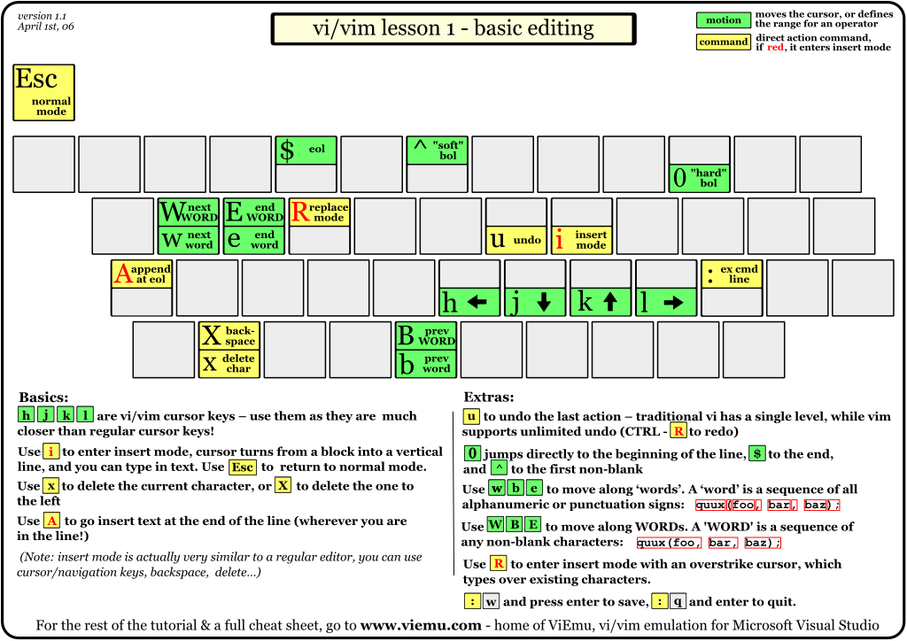

# Operators and repetition

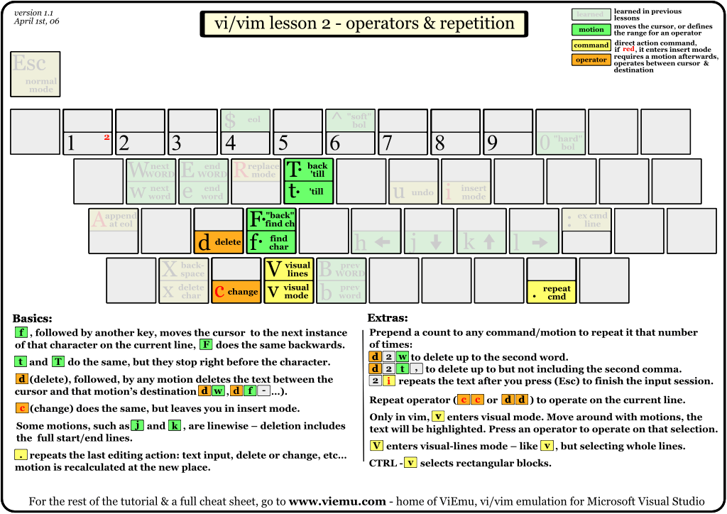

# Yank & paste

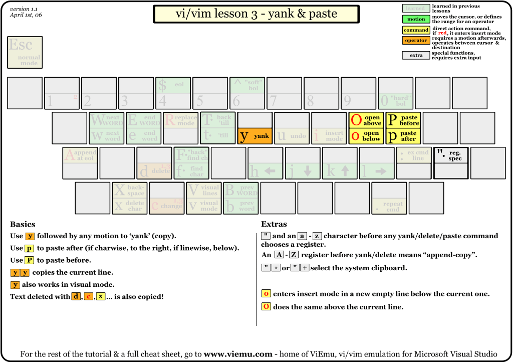

# Searching

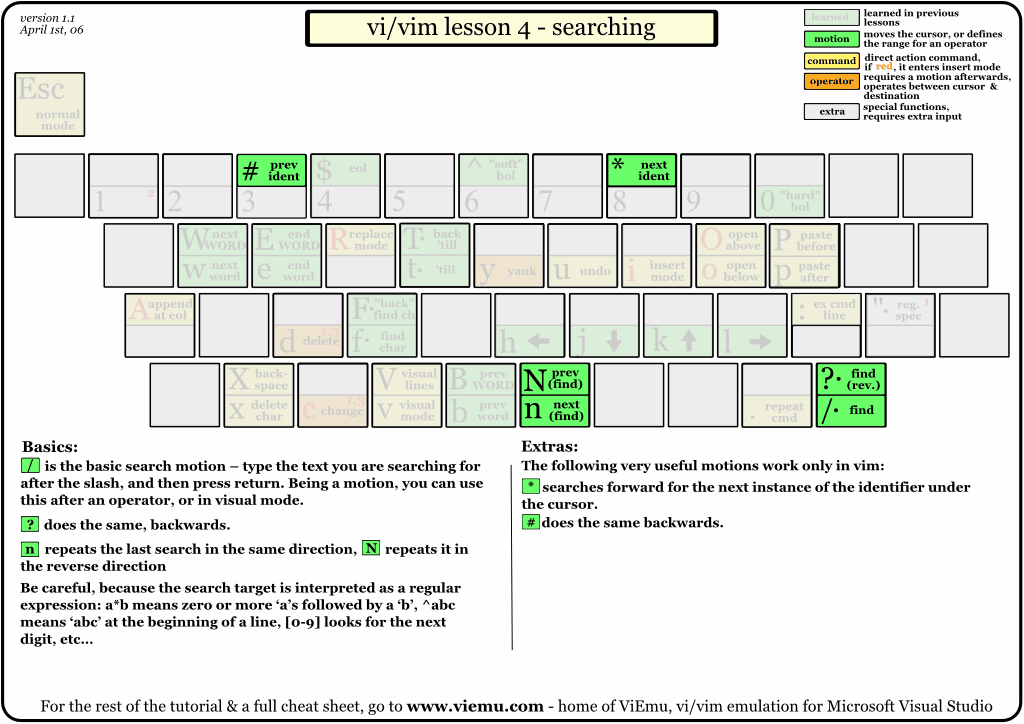

# Marks & macros

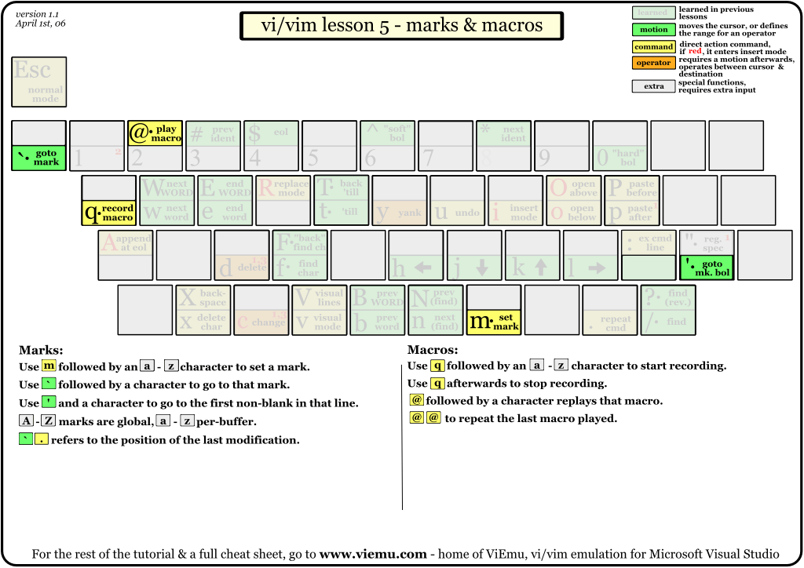

# Various motions

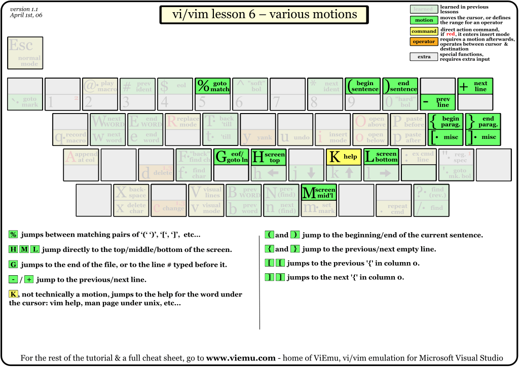

# Various commands

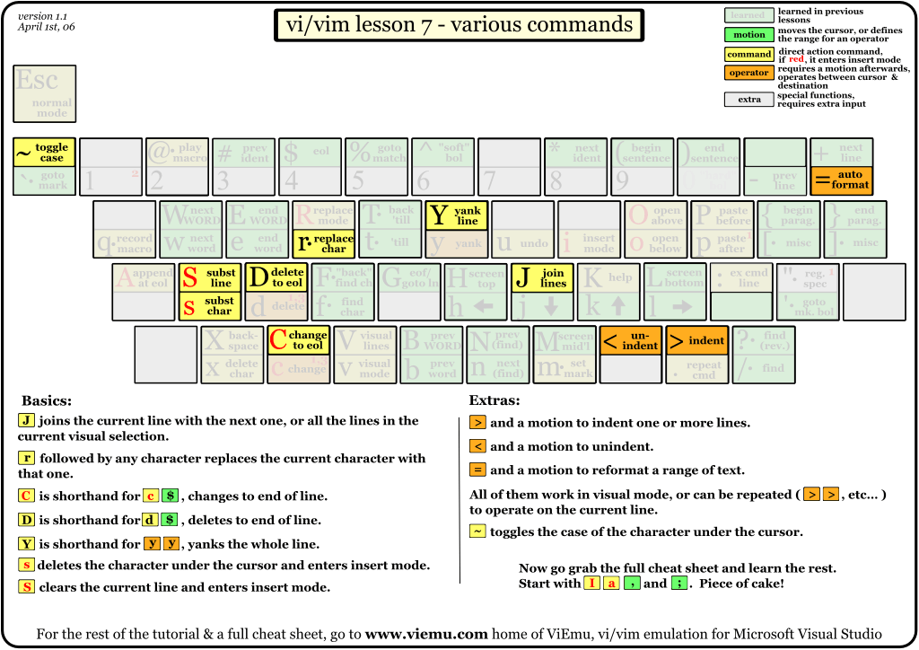

# Places to learn

- The [pictorial cheatsheets](http://www.viemu.com/a_vi_vim_graphical_cheat_sheet_tutorial.html) used in this slide
  - [Color PDF of all 8 diagrams](http://www.glump.net/_media/howto/vi-vim-cheat-sheet-and-tutorial.pdf)
- A nice [introduction with some clear prose](http://jmcpherson.org/editing.html)
- A popular portal to [the rest of the vim universe](http://thomer.com/vi/vi.html)
- A bit heavy-handed for my taste, but if you really like learning by [watching over someone's shoulder](http://www.linuxconfig.org/Vim_Tutorial)...
- Lastly, if you just want to learn [how to start *and* quit vim all in the first page of tips](http://www.jerrywang.net/vi/)